# Think Believe 2 (free response)

In this notebook we analyze the second “think/believe” task, in which participants completed a series of fill-in-the-blanks with free responses.

Note: We have used a combination of automatic “lemmatization” and hand-coding to do our best to code whether responses should count as “believe” (e.g., including obvious cases like “believes” and “believed”; including Bislama “belif” and “bilif” and other spellings).

We provide two versions of these variables – one that only includes responses that are strictly “believe” and one that also includes cases that involve the word “believe” (e.g., “firmly believes,” “does not believe”) – and likewise for think. The looser interpretations are called `believeX` (or “belief*”) and `thinkX` (or “think*”). These looser interpretations are the variables that are the focus of the current analyses.

# Overview

From the preregistration:

> “Our overarching hypothesis for the present study is that […] other languages will have an epistemic verb that is more likely to be used for religious attitude reports (similar to English “believe”) and a different epistemic verb that is more likely to be used for matter-of-fact attitude reports (similar to English “think”).

> For this study, we are examining five languages in five regions of interest: (i) Mandarin in China; (ii) Thai in Thailand; (iii) Bislama (an English-based creole language) on the Melanesian Island of Vanuatu; (iv) Fante in Ghana; and (v) American English in the Bay Area, California.

> We thus have five more specific sub-hypotheses. For each of the first four languages / regions of interest, we hypothesize that a set of words or phrases exists whose usage parallels the difference between usage of “think” and “believe” in American English, with one word or phrase (the “think” analogue) being used for more matter-of-fact attitude reports and the other (the “believe” analogue) being more likely to be used for religious attitude reports. That gives us our first four sub-hypotheses: that Mandarin, Thai, Bislama and Fante speakers will each use two different words in a manner parallel to the use of “think” and “believe” in an American English setting as identified by Heiphetz, Landers, and Van Leeuwen. Our fifth sub-hypothesis is that the Bay Area portion of the study will replicate the results of the earlier study of Heiphetz, Landers, and Van Leeuwen."

**SUMMARY: We replicated the original finding in the US (and the findings of Think Believe 1): participants were more likely to write in “believe” for religious than fact questions. We found the same pattern in all five countries/langauges included in this study.**

# Samples

Before we begin, it’s important to note that we had unequal sample sizes by country:

```
 thb2_ctry   n
        US 103
     Ghana  49
  Thailand 106
     China 100
   Vanuatu 100
     Total 458
```

However, 39 participants completed this task after completing other surveys, and an additional 31 failed the attention check. In the following analyses we will exclude these participants, leaving us with the following samples:

```
  country   n
       US  71
    Ghana  46
 Thailand  98
    China 100
  Vanuatu  73
    Total 388
```

# Plots

We’ll begin by plotting responses of “think(s)/thought” (red) vs. “believe(s)/believed” (turquoise) vs. other responses (gray) to get an overall sense of any patterns in the data.

## By superordinate category

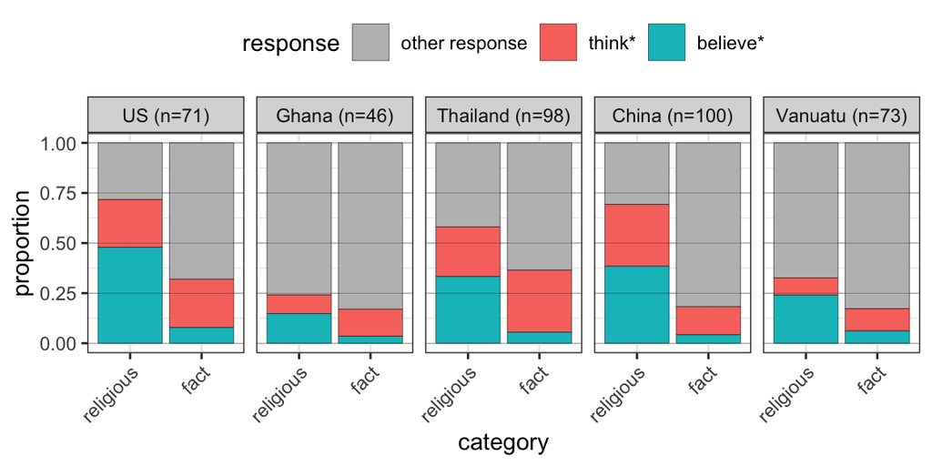

## By category

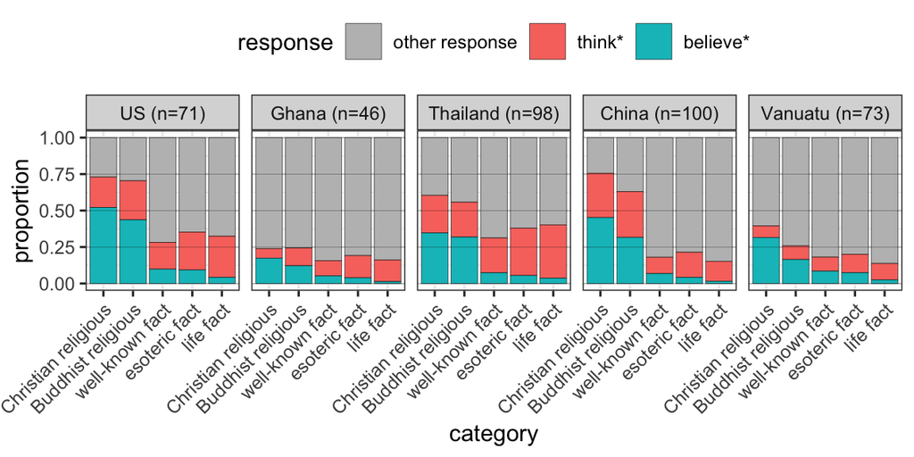

## By question

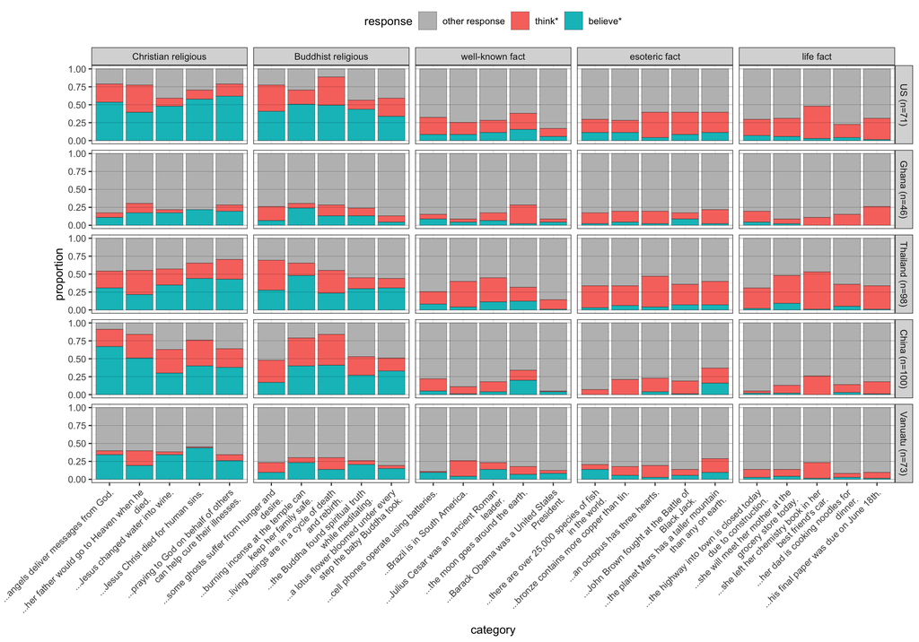

# Analysis: without looking at preregistration

These analyses directly parallel the way we analyzed the Think Believe 1 data before looking at the preregistration. Again, we think these analyses are valuable because they’re a little more efficient than the preregistered analyses – no need for follow-up tests – and they directly test the question of whether the effect of interest varies across countries/langauges.

As of 2020-01-22, we’re now using the more lenient “believe*” variable in these analyses.

Technical note: Unless specified otherwise, all of these analyses use “effect coding” for categorical variables (e.g., country, category of question) – meaning that each country/langauge is compared to the “grand mean” collapsing across all countries/languages. Because of degrees of freedom issues, each analysis only compares 4 of the 5 countries to the grand mean – by default, we’ve left out the comparison of the US/English to the grand mean, but stats for that comparison could easily be calculated (if we left out another country/language instead). This is just to say that you won’t see statements like “The effect was exaggerated in the US relative to other countries,” although they might be true.

## Analysis #1

Note that this analysis treats responses of “think” as the same as any other non-“believe” response.

```r
r2.1 <- lmer(believeX ~ super_cat * country
             + (1 + super_cat | thb2_subj) + (1 | question),
             data = d2_long)
```

| Parameter | β | Std. Err. | df | t | p |  |
| --- | --- | --- | --- | --- | --- | --- |
| Intercept | 0.19 | 0.01 | 55.49 | 13.80 | <0.001 | *** |
| Category (religious) | 0.13 | 0.01 | 40.79 | 10.58 | <0.001 | *** |
| Country (Gh.) | -0.09 | 0.02 | 383.00 | -4.57 | <0.001 | *** |
| Country (Th.) | 0.01 | 0.02 | 383.00 | 0.55 | 0.584 |  |
| Country (Ch.) | 0.03 | 0.02 | 383.00 | 1.80 | 0.073 |  |
| Country (Vt.) | -0.03 | 0.02 | 383.00 | -2.03 | 0.043 | * |
| Category (religious) × Country (Gh.) | -0.07 | 0.02 | 383.01 | -4.53 | <0.001 | *** |
| Category (religious) × Country (Th.) | 0.01 | 0.01 | 383.01 | 0.61 | 0.541 |  |
| Category (religious) × Country (Ch.) | 0.04 | 0.01 | 383.01 | 3.24 | 0.001 | ** |
| Category (religious) × Country (Vt.) | -0.04 | 0.01 | 383.01 | -3.05 | 0.002 | ** |

**Take-away: The predicted effect is evident in this dataset, as it was in Think Believe 1. It appears to be exaggerated in China and diminished in Ghana and Vanuatu, a pattern which differs from Think Believe 1.**

## Analyses #1a-1e (by country)

Next, we did this same analysis within each country/langauge alone (using the most maximal random effect structure that converged across all countries/languages).

```r
# note: using most maximal common random effects structure
r2.1_us <- lmer(believeX ~ super_cat +
                  # (1 + super_cat | thb2_subj) + (1 | question),
                  # (1 + super_cat || thb2_subj) + (1 | question), # failed to converge
                  (1 | thb2_subj) + (1 | question),
                  # (1 + super_cat | thb2_subj),
                  # (1 + super_cat || thb2_subj),
                  # (1 | thb2_subj),
                data = d2_long %>% filter(country == "US"))

r2.1_gh <- lmer(believeX ~ super_cat +
                  # (1 + super_cat | thb2_subj) + (1 | question),
                  # (1 + super_cat || thb2_subj) + (1 | question),
                  (1 | thb2_subj) + (1 | question),
                  # (1 + super_cat | thb2_subj),
                  # (1 + super_cat || thb2_subj),
                  # (1 | thb2_subj),
                data = d2_long %>% filter(country == "Ghana"))

r2.1_th <- lmer(believeX ~ super_cat +
                  # (1 + super_cat | thb2_subj) + (1 | question), # failed to converge
                  # (1 + super_cat || thb2_subj) + (1 | question), # failed to converge
                  (1 | thb2_subj) + (1 | question),
                  # (1 + super_cat | thb2_subj),
                  # (1 + super_cat || thb2_subj),
                  # (1 | thb2_subj),
                data = d2_long %>% filter(country == "Thailand"))

r2.1_ch <- lmer(believeX ~ super_cat +
                  # (1 + super_cat | thb2_subj) + (1 | question),
                  # (1 + super_cat || thb2_subj) + (1 | question),
                  (1 | thb2_subj) + (1 | question),
                  # (1 + super_cat | thb2_subj),
                  # (1 + super_cat || thb2_subj),
                  # (1 | thb2_subj),
                data = d2_long %>% filter(country == "China"))

r2.1_vt <- lmer(believeX ~ super_cat +
                  # (1 + super_cat | thb2_subj) + (1 | question),
                  # (1 + super_cat || thb2_subj) + (1 | question), # failed to converge
                  (1 | thb2_subj) + (1 | question),
                  # (1 + super_cat | thb2_subj),
                  # (1 + super_cat || thb2_subj),
                  # (1 | thb2_subj),
                data = d2_long %>% filter(country == "Vanuatu"))
```

| Country | Parameter | β | Std. Err. | df | t | p |  |
| --- | --- | --- | --- | --- | --- | --- | --- |
| US | Intercept | 0.28 | 0.02 | 64.60 | 13.86 | <0.001 | *** |
| US | Category (religious) | 0.20 | 0.01 | 23.00 | 15.84 | <0.001 | *** |
| Ghana | Intercept | 0.09 | 0.02 | 49.60 | 4.47 | <0.001 | *** |
| Ghana | Category (religious) | 0.06 | 0.01 | 23.00 | 6.07 | <0.001 | *** |
| Thailand | Intercept | 0.19 | 0.02 | 78.96 | 9.90 | <0.001 | *** |
| Thailand | Category (religious) | 0.14 | 0.01 | 23.00 | 10.83 | <0.001 | *** |
| China | Intercept | 0.21 | 0.02 | 37.51 | 9.44 | <0.001 | *** |
| China | Category (religious) | 0.17 | 0.02 | 23.00 | 8.64 | <0.001 | *** |
| Vanuatu | Intercept | 0.15 | 0.02 | 62.67 | 7.02 | <0.001 | *** |
| Vanuatu | Category (religious) | 0.09 | 0.02 | 23.00 | 5.89 | <0.001 | *** |

The effects of primary interest are in bold, and **the take-away is clear: In every country/language, participants were more likely to say “believe” in “religious” questions than in “fact” questions**.

## Analysis #2

In this analysis, we treated country/language as a random rather than fixed effect (with participants nested within countries).

```r
r2.2 <- lmer(believeX ~ super_cat
             # + (1 + super_cat | country/thb2_subj) + (1 | question), # failed to converge
             # + (1 + super_cat || country/thb2_subj) + (1 | question), # failed to converge
             # + (1 + super_cat | country/thb2_subj),
             # + (1 + super_cat || country/thb2_subj), # failed to converge
             + (1 | country/thb2_subj) + (1 | question),
             # + (1 | country/thb2_subj),
             data = d2_long)
```

| Parameter | β | Std. Err. | df | t | p |  |
| --- | --- | --- | --- | --- | --- | --- |
| Intercept | 0.19 | 0.03 | 5.12 | 6.82 | <0.001 | *** |
| Category (religious) | 0.14 | 0.01 | 23.00 | 13.00 | <0.001 | *** |

The effect still holds.

## Analysis #3

Finally, we ran a version of this first model looking at 5 categories of questions (rather than 2 superordinate categories): Christian religious, Buddhist religious, well-known fact, esoteric fact, and personal fact. We compared these categories using planned orthogonal contrasts.

```r
r2.3 <- lmer(believe ~ category2 * country
             # + (1 + category2 | thb2_subj) + (1 | question), # ranfx cor > 0.9
             # + (1 + category2 || thb2_subj) + (1 | question), # ranfx cor > 0.9
             # + (1 + category2 | thb2_subj), # ranfx cor > 0.9
             # + (1 + category2 || thb2_subj),
             + (1 | thb2_subj) + (1 | question), # match to study 1
             data = d2_long)
```

| Parameter | β | Std. Err. | df | t | p |  |
| --- | --- | --- | --- | --- | --- | --- |
| Intercept | 0.15 | 0.01 | 53.94 | 14.21 | <0.001 | *** |
| Contrast A | 0.05 | 0.00 | 20.46 | 14.73 | <0.001 | *** |
| Contrast B | 0.01 | 0.01 | 418.34 | 2.31 | 0.022 | * |
| Contrast C | 0.01 | 0.01 | 20.46 | 1.73 | 0.098 |  |
| Contrast D | 0.01 | 0.01 | 20.46 | 0.53 | 0.599 |  |
| Country (Gh.) | -0.07 | 0.02 | 383.00 | -4.09 | <0.001 | *** |
| Country (Th.) | 0.01 | 0.01 | 383.00 | 0.55 | 0.584 |  |
| Country (Ch.) | 0.00 | 0.01 | 383.00 | 0.28 | 0.780 |  |
| Country (Vt.) | -0.02 | 0.01 | 383.00 | -1.48 | 0.139 |  |
| Contrast A × Country (Gh.) | -0.03 | 0.00 | 9272.00 | -8.82 | <0.001 | *** |
| Contrast B × Country (Gh.) | 0.01 | 0.02 | 96.57 | 0.83 | 0.408 |  |
| Contrast C × Country (Gh.) | 0.00 | 0.01 | 9272.00 | -0.34 | 0.734 |  |
| Contrast D × Country (Gh.) | 0.00 | 0.01 | 9272.00 | -0.05 | 0.964 |  |
| Contrast A × Country (Th.) | 0.00 | 0.00 | 9272.00 | 1.67 | 0.094 |  |
| Contrast B × Country (Th.) | -0.02 | 0.02 | 28.59 | -1.41 | 0.170 |  |
| Contrast C × Country (Th.) | -0.01 | 0.01 | 9272.00 | -1.09 | 0.274 |  |
| Contrast D × Country (Th.) | 0.00 | 0.01 | 9272.00 | 0.34 | 0.733 |  |
| Contrast A × Country (Ch.) | 0.01 | 0.00 | 9272.00 | 4.12 | <0.001 | *** |
| Contrast B × Country (Ch.) | -0.08 | 0.02 | 28.37 | -4.64 | <0.001 | *** |
| Contrast C × Country (Ch.) | 0.00 | 0.01 | 9272.00 | -0.18 | 0.859 |  |
| Contrast D × Country (Ch.) | 0.00 | 0.01 | 9272.00 | 0.21 | 0.833 |  |
| Contrast A × Country (Vt.) | -0.02 | 0.00 | 9272.00 | -5.73 | <0.001 | *** |
| Contrast B × Country (Vt.) | 0.06 | 0.01 | 64.16 | 4.41 | <0.001 | *** |
| Contrast C × Country (Vt.) | 0.00 | 0.01 | 9272.00 | 0.77 | 0.440 |  |
| Contrast D × Country (Vt.) | 0.00 | 0.01 | 9272.00 | -0.02 | 0.982 |  |

```r
r2.3b <- lmer(believe ~ category2 * country
             # + (1 + category2 | thb1_subj) + (1 | question), # failed to converge
             # + (1 + category2 || thb1_subj) + (1 | question), # failed to converge
             # + (1 + category2 | thb1_subj), # failed to converge
             # + (1 + category2 || thb1_subj),
             + (1 | thb2_subj) + (1 | question),
             contrasts = list(country = "contr.sum"),
             data = d2_long)
```

The first orthogonal contrast compared the two “religious” categories to the three “fact” categories (“Category (Religious vs. fact)”). This parallels the previous analyses, and the results are similar: Overall, participants were more likely to circle “believe” for religious questions than fact questions, and this tendency was diminished in Ghana and Vanuatu, and exaggerated in China.

The second orthogonal contrast compared local to other “religious” questions (crudely defining “local” as Christian for participants in the US, Ghana, and Vanuatu, and Buddhist for participants in Thailand and China). Overall, participants were more likely to circle “believe” for religious questions from a local religion, and this tendency was exaggerated in Vanuatu (a predominantly Christian samples) and diminished in China (an overwhelmingly non-religious sample).

The third orthogonal contrast compared well-known facts, on the one hand, to esoteric and personal facts, on the other. Overall, participants were no more or less likely to circle “believe” in either case.

The fourth orthogonal contrast compared esoteric to personal life facts. Overall, particpants were no more or less likely to circle “believe” in either case.

# Analysis: Based on preregistration

From preregistration:

> “Survey 1: We will conduct a 5 (Site: China vs. Thailand vs. Vanuatu vs. Ghana vs. United States) x 2 (Statement Type: religion vs. fact) mixed ANOVA with repeated measures on the second factor and the proportion of trials on which participants completed sentences using a form the word “believe” (or its respective translation) as the dependent measure. To look for finer-grained differences between different religious and factual statements, we will also conduct a 5 (Site: China vs. Thailand vs. Vanuatu vs. Ghana vs. United States) x 5 (Statement Type: Buddhist religious statements vs. Christian religious statements vs. life facts vs. well-known facts vs. esoteric facts) mixed ANOVA with repeated measures on the second factor and the proportion of trials on which participants completed sentences using a form of the word “believe” (or its respective translation) as the dependent measure. In all cases where omnibus ANOVAs are significant, we will conduct pairwise analyses comparing each statement type with each other statement type and each site with each other site."

```r
d2_anova <- d2_long %>%
  distinct(thb2_subj, country, super_cat, question, believeX) %>%
  group_by(thb2_subj, country, super_cat) %>%
  summarise(prop_believeX = mean(believeX)) %>%
  ungroup() %>%
  mutate(thb2_subj = factor(thb2_subj))
contrasts(d2_anova$country) <- contrast_country
contrasts(d2_anova$super_cat) <- contrast_super_cat
```

## Prereg Analysis #1

Here is the first preregistered analyis: a 5 (country) x 2 (question category) mixed ANOVA with repeated measures on the second factor and the proportion of trials on which participants wrote “berlieve” as the DV.

```r
r2.4 <- d2_anova %>%
  anova_test(dv = "prop_believeX",
             wid = "thb2_subj",
             between = "country",
             within = "super_cat",
             observed = "country")

get_anova_table(r2.4)
```

```
ANOVA Table (type III tests)

             Effect DFn DFd       F        p p<.05   ges
1           country   4 383  10.868 2.35e-08     * 0.062
2         super_cat   1 383 359.606 5.00e-57     * 0.246
3 country:super_cat   4 383  12.586 1.25e-09     * 0.046
```

This analysis aligns with the regressions above and with Think Believe 1, suggesting that participants’ tendency to write “believe” varied by country/language (`country`) and by question category (`super_cat`), and the difference between question category varied across countries/languages (i.e., there was an interaction: `country:super_cat`).

The preregistration indicated that we’d conduct pairwise follow-up analyses comparing the two question categories and comparing pairs of countires/languages – but, again, we don’t really think we’re interested in comparing pairs of countries/languages, so we’ll going to skip that for now. Instead, we’ll compare the two questions categories within each country/language (to explore the significant interaction), as we did for Think Believe 1.

Follow-up analysis below.

### Comparing question categories

```r
r2.5a <- t.test(prop_believeX ~ super_cat, paired = T, d2_anova); r2.5a
```

```
    Paired t-test

data:  prop_believeX by super_cat
t = 19.793, df = 387, p-value < 2.2e-16
alternative hypothesis: true difference in means is not equal to 0
95 percent confidence interval:
 0.2509326 0.3062839
sample estimates:
mean of the differences
              0.2786082
```

[output not shown]

### Comparing question categories within countries/languages

```r
# US
r2.5b_us <- t.test(prop_believeX ~ super_cat, paired = T,
                   d2_anova %>% filter(country == "US")); r2.5b_us
```

```
    Paired t-test

data:  prop_believeX by super_cat
t = 11.476, df = 70, p-value < 2.2e-16
alternative hypothesis: true difference in means is not equal to 0
95 percent confidence interval:
 0.3312579 0.4706201
sample estimates:
mean of the differences
               0.400939
```

```r
# Ghana
r2.5b_gh <- t.test(prop_believeX ~ super_cat, paired = T,
                   d2_anova %>% filter(country == "Ghana")); r2.5b_gh
```

```
    Paired t-test

data:  prop_believeX by super_cat
t = 4.0562, df = 45, p-value = 0.0001957
alternative hypothesis: true difference in means is not equal to 0
95 percent confidence interval:
 0.05691244 0.16917452
sample estimates:
mean of the differences
              0.1130435
```

```r
# Thailand
r2.5b_th <- t.test(prop_believeX ~ super_cat, paired = T,
                   d2_anova %>% filter(country == "Thailand")); r2.5b_th
```

```
    Paired t-test

data:  prop_believeX by super_cat
t = 9.7482, df = 97, p-value = 4.691e-16
alternative hypothesis: true difference in means is not equal to 0
95 percent confidence interval:
 0.2210417 0.3340604
sample estimates:
mean of the differences
               0.277551
```

```r
# China
r2.5b_ch <- t.test(prop_believeX ~ super_cat, paired = T,
                   d2_anova %>% filter(country == "China")); r2.5b_ch
```

```
    Paired t-test

data:  prop_believeX by super_cat
t = 12.57, df = 99, p-value < 2.2e-16
alternative hypothesis: true difference in means is not equal to 0
95 percent confidence interval:
 0.2880159 0.3959841
sample estimates:
mean of the differences
                  0.342
```

```r
# Vanuatu
r2.5b_vt <- t.test(prop_believeX ~ super_cat, paired = T,
                   d2_anova %>% filter(country == "Vanuatu")); r2.5b_vt
```

```
    Paired t-test

data:  prop_believeX by super_cat
t = 6.8338, df = 72, p-value = 2.235e-09
alternative hypothesis: true difference in means is not equal to 0
95 percent confidence interval:
 0.1264582 0.2306194
sample estimates:
mean of the differences
              0.1785388
```

**The difference between question categories was significant in each country/language considered alone.**

## Prereg Analysis #2

```r
d2b_anova <- d2_long %>%
  distinct(thb2_subj, country, category, question, believeX) %>%
  group_by(thb2_subj, country, category) %>%
  summarise(prop_believeX = mean(believeX)) %>%
  ungroup() %>%
  mutate(thb2_subj = factor(thb2_subj))
contrasts(d2b_anova$country) <- contrast_country
contrasts(d2b_anova$category) <- contrast_category
```

Here is the second preregistered analyis: a 5 (country) x 5 (question sub-category) mixed ANOVA with repeated measures on the second factor and the proportion of trials on which participants included the word stem “believe” in their free respones as the DV.

```r
r2.10 <- d2b_anova %>%
  anova_test(dv = "prop_believeX",
             wid = "thb2_subj",
             between = "country",
             within = "category",
             observed = "country")

get_anova_table(r2.10)
```

```
ANOVA Table (type III tests)

            Effect  DFn    DFd       F        p p<.05   ges
1          country 4.00 383.00   9.919 1.20e-07     * 0.040
2         category 2.29 876.25 231.171 3.11e-90     * 0.240
3 country:category 9.15 876.25   8.514 1.92e-12     * 0.046
```

This analysis aligns with the regressions above, suggesting that participants’ tendency to use “believe” varied by country/language (`country`) and by question category (`category`), and the difference between question category varied across countries/languages (i.e., there was an interaction: `country:category`).

| country | OVERALL | Christian religious | Buddhist religious | well-known fact | esoteric fact | life fact |
| --- | --- | --- | --- | --- | --- | --- |
| US | 0.24 | 0.52 | 0.44 | 0.10 | 0.09 | 0.04 |
| Ghana | 0.08 | 0.17 | 0.12 | 0.05 | 0.04 | 0.01 |
| Thailand | 0.17 | 0.35 | 0.32 | 0.07 | 0.06 | 0.04 |
| China | 0.18 | 0.45 | 0.32 | 0.07 | 0.04 | 0.02 |
| Vanuatu | 0.13 | 0.32 | 0.16 | 0.08 | 0.07 | 0.02 |
| OVERALL | 0.17 | 0.38 | 0.29 | 0.08 | 0.06 | 0.03 |

# Free response data

Here’s a very quick pass at looking at the most common words/phrases in these free responses – we did a quick and dirty “stemming” (converting, e.g., “believe” and “believes” and “believed” all to the stem “believ”) but we could look into doing something more sophisticated. Here are the top 5 stems for each question category, by country:

| country | super_cat | category | response_lemma2 | percent | n |
| --- | --- | --- | --- | --- | --- |
| US | religious | Christian religious | believe | 52% | 184 |
| US | religious | Christian religious | think | 21% | 74 |
| US | religious | Christian religious | say | 10% | 37 |
| US | religious | Christian religious | know | 5% | 17 |
| US | religious | Christian religious | read | 2% | 8 |
| US | religious | Buddhist religious | believe | 43% | 154 |
| US | religious | Buddhist religious | think | 27% | 95 |
| US | religious | Buddhist religious | say | 9% | 32 |
| US | religious | Buddhist religious | know | 4% | 15 |
| US | religious | Buddhist religious | learn | 4% | 15 |
| US | fact | well-known fact | know | 45% | 158 |
| US | fact | well-known fact | think | 18% | 65 |
| US | fact | well-known fact | believe | 10% | 35 |
| US | fact | well-known fact | say | 8% | 29 |
| US | fact | well-known fact | learn | 5% | 16 |
| US | fact | esoteric fact | think | 26% | 92 |
| US | fact | esoteric fact | know | 19% | 69 |
| US | fact | esoteric fact | say | 11% | 38 |
| US | fact | esoteric fact | believe | 9% | 33 |
| US | fact | esoteric fact | learn | 8% | 29 |
| US | fact | life fact | think | 28% | 100 |
| US | fact | life fact | say | 16% | 58 |
| US | fact | life fact | know | 15% | 55 |
| US | fact | life fact | forget | 5% | 16 |
| US | fact | life fact | believe | 4% | 15 |
| Ghana | religious | Christian religious | know | 29% | 67 |
| Ghana | religious | Christian religious | believe | 17% | 40 |
| Ghana | religious | Christian religious | say | 16% | 36 |
| Ghana | religious | Christian religious | hear | 12% | 27 |
| Ghana | religious | Christian religious | see | 7% | 17 |

[output cut: 97 more lines]

There’s lots to discuss here – e.g., the common use of “know” (which is already of interest). Also, the Bislama data appears to be in Bislama (not translated) – we’ve included “bilif” (and spelling variants) as “believe” and “ting” (as spelling variants) as “think” in all of the foregoing analyses.

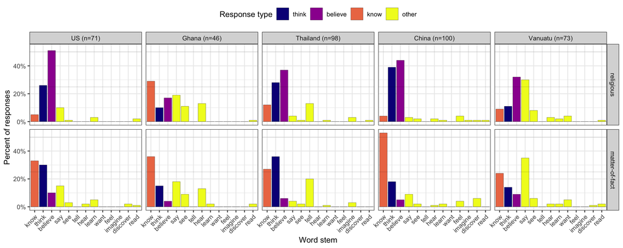

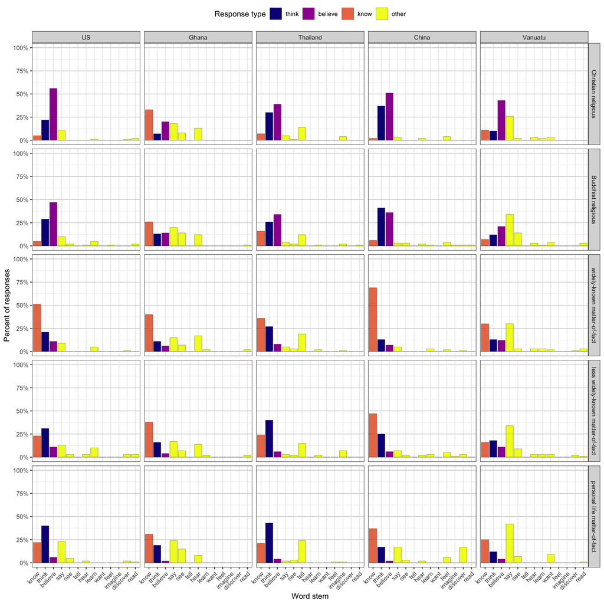

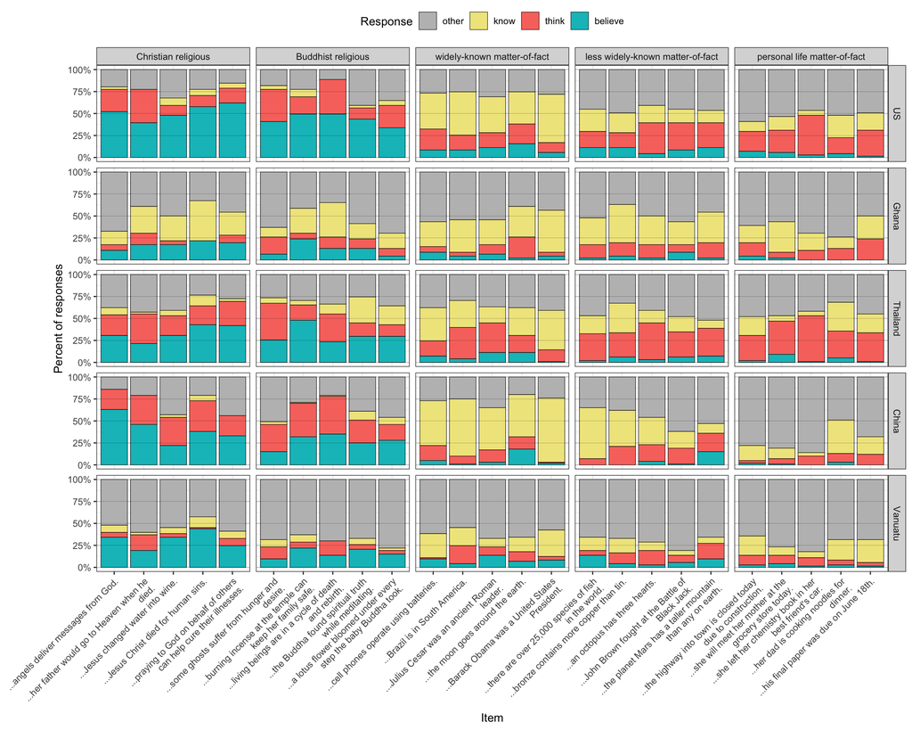

# Demographics

| country | n |
| --- | --- |
| US | 71 |
| Ghana | 46 |
| Thailand | 98 |
| China | 100 |
| Vanuatu | 73 |

| country | min | max | mean |
| --- | --- | --- | --- |
| US | 18 | 30 | 19.55 |
| Ghana | 18 | 65 | 31.11 |
| Thailand | 18 | 22 | 19.45 |
| China | 18 | 24 | 19.85 |
| Vanuatu | 16 | 25 | 20.04 |

| country | Male | Female | Other | <NA> |
| --- | --- | --- | --- | --- |
| US | 0.58 | 0.39 | NA | 0.03 |
| Ghana | 0.39 | 0.61 | NA | NA |
| Thailand | 0.78 | 0.20 | 0.01 | 0.01 |
| China | 0.49 | 0.50 | 0.01 | NA |
| Vanuatu | 0.45 | 0.42 | NA | 0.12 |

| country | thb2_demo_rely_num | thb2_demo_impr_num | thb2_demo_wors_num | thb2_demo_bgod_num | thb2_demo_bbuh_num | thb2_demo_bosp_num | thb2_demo_atsn_num | thb2_demo_imsn_num |
| --- | --- | --- | --- | --- | --- | --- | --- | --- |
| US | 2.23 | 2.18 | 1.65 | 1.59 | 0.71 | 0.41 | 2.13 | 2.43 |
| Ghana | 4.89 | 4.87 | 3.54 | 2.98 | 0.57 | 0.61 | 3.04 | 4.30 |
| Thailand | NaN | NaN | 2.29 | 1.59 | 2.21 | 1.82 | 2.36 | 3.64 |
| China | 1.15 | 1.25 | 0.53 | 0.78 | 0.72 | 0.61 | 1.96 | 2.54 |
| Vanuatu | 3.76 | 3.79 | 3.50 | 2.88 | 0.39 | 0.56 | 2.01 | 2.58 |

| country | thb2_religion | NO | YES | <NA> |
| --- | --- | --- | --- | --- |
| US | Buddhist | NA | 0.01 | NA |
| US | Christian | NA | 0.08 | NA |
| US | Other | NA | 0.04 | NA |
| US | NA | 0.86 | NA | NA |
| Ghana | Christian | NA | 0.87 | NA |
| Ghana | Other | NA | 0.11 | NA |
| Ghana | NA | 0.02 | NA | NA |
| Thailand | Buddhist | NA | 0.17 | NA |
| Thailand | Christian | NA | 0.04 | NA |
| Thailand | Other | NA | 0.09 | NA |

[output cut: 8 more lines]